# Release Notes for Insurance Marketing Score

Author

Robert Kubinec

This document describes the approach for targeting uninsured people in the Houston market for a new push by Texas Monopoly Health (TMH). I first discuss the data provided by TMH and what we can learn from it about the Texas health insurance market. Then I show scores that I derived to indicate which potential customers are the most likely to purchase health insurance if they received advertising about the availability of the health insurance plan. I show how these scores could be used to determine the optimal amount of funding to allocate to advertising given TMH’s marginal revenue and marginal costs from offering new health insurance plans.

## Describing the Texas Health Insurance Market

TMH provided a dataset with 7,500 Texans, 50% of whom have insurance with TMH.[^1] While we do not know exactly how TMH created the dataset, it does appear to be broadly representative of Texans. 53% of the subjects in the data are women and 81% are married. The plot below shows the distribution of people in the data in terms of their age (on the x axis) and income (on the y axis):

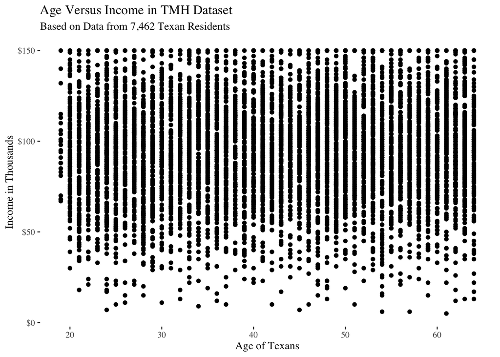

This plot shows that the dataset include Texans both young and old and rich and poor. We might be surprised at the fact that older people are not richer on average, but perhaps Texas is a special place where the young and old have equal opportunities and wealth endowments.

One particular concern that has arisen during our analysis of the data is how racial identity and education interact in terms of insurance. The plot below shows average numbers of insured people in terms of their education and self-reported racial identity:

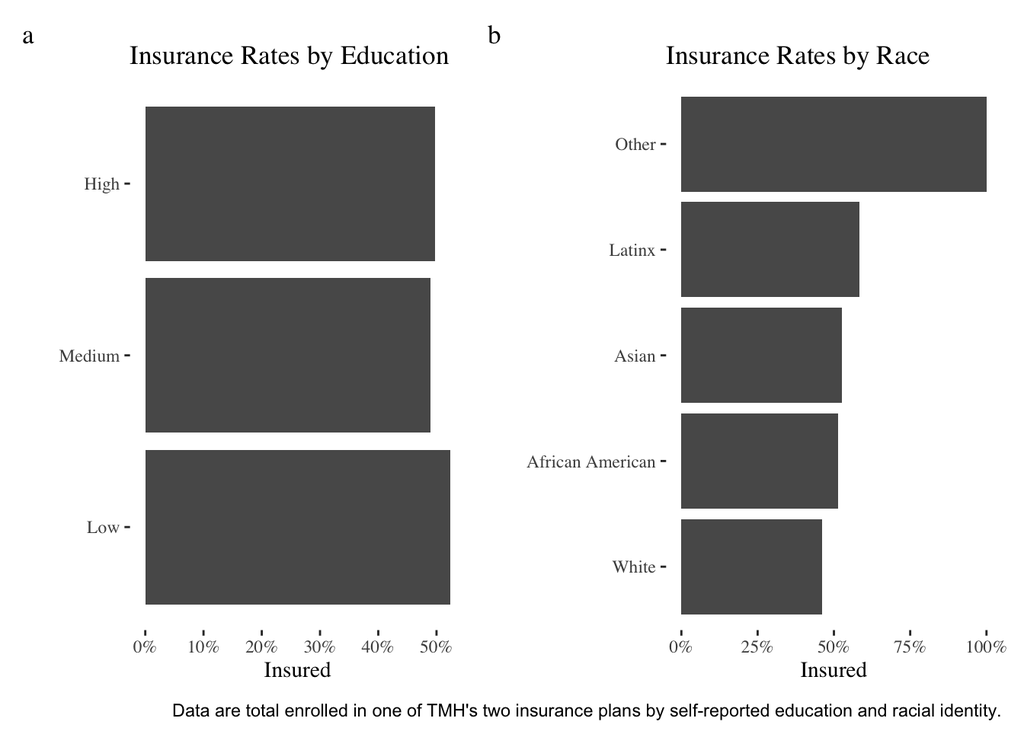

Based on the average insurance rates from the dataset shown above, there appear to be only minor differences across educational categories and some differences for ethnicities. However, the differences are not pronounced, except for the “Other” ethnicity category.

However, if we calculate the number of insured by each intersection of race and education, we can see which sub-groups have the highest proportion of uninsured overall:

| Education | Race | % Uninsured |
| --- | --- | --- |
| High | Asian | 31 |
| Low | Latinx | 22 |
| High | White | 21 |
| Low | African American | 20 |
| Medium | White | 18 |
| Medium | African American | 17 |
| Low | White | 15 |
| High | African American | 12 |
| Medium | Latinx | 11 |
| Medium | Asian | 9 |
| High | Latinx | 8 |
| Low | Asian | 7 |

This table shows us that while insurance rates do not vary significantly by education in the aggregate, when we examine the intersection of race and ethnicity, we find significant discrepancies. Self-reported Asian ancestry people with low education have an uninsurance rate of only 7%, while self-reported Asians with high education have an uninsurance of 31%. Conversely, Latinx Texans with high education have an uninsurance rate of only 8% while low-education Latinx have an uninsurance rate of 22%. This disaggregated data shows us we need to be careful when looking at aggregate rates among Texans as in plots (a) and (b) as it can mask a lot of differences within ethnic and racial categories.

Finally we can explore the geographic diversity of the Texan health insurance market by plotting the % insured for each county:

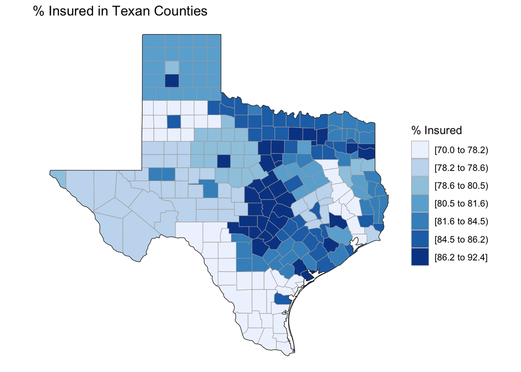

We can see from this plot that insurance rates are highly clustered in certain regions of the state. The central part of the state has the highest insured rates while the southern part has the lowest. For this reason, incorporating geography is important to understand the Texas healthcare market.

## Targeting Scores

Based on the individual level TMH data—combined with demographic information at the county level—I created targeting scores that are the probability that people present in the Houston dataset would subscribe to insurance in the event that coverage were available to them. These targeting scores predict whether a Houston resident will purchase one of the two plans; they do not differentiate between plans, although it is straightforward to extend the scores to predict a specific plan if that is what the client needs.

Three targeting scores are derived based on contrasting modeling approaches. Examining contrasting techniques allows me to provide the client multiple options as well as to explore what different models say about the data. I employed measures of predictive accuracy to evaluate the models; in other words, the targeting scores that I include in the attached file are those that seem to most accurately predict having insurance in the TMH data from across Texas (excluding Houston). These models are then used to predict those people in Houston who are most likely to purchase insurance under the assumption that the only reason they have not purchased insurance before is because it was not available from TMH.

The two models employed were what I call an “aggressive” approach with random forests and a “conservative” approach with Bayesian multilevel models. Without entering into the technical details, the two approaches can be contrasted in terms of how much they rely on the data provided. The random forests model uses all of the available predictors in the TMH data at both the individual and county level and also allows for possibly quite nuanced relationships between predictors. The Bayesian multilevel model, on the other hand, adopts a conservative approach in that it only uses a subset of predictors that seem most relevant to purchasing insurance and a simpler additive structure to relate the predictors to the outcome. In addition, the Bayesian model explicitly accounts for the clustering of individuals within counties.

In essence, the aggressive approach soaks up all of the information in the data, eking out every bit of information in the data about purchasing insurance. The conservative approach by contrast uses a simpler structure that is easier to interpret by utilizing much of, but not all, the information in the data. The conservative approach’s advantage is that it is less sensitive to the data, and so if we have reason to mistrust the data at hand, the conservative approach may also be less error-prone when we apply it to the real world.

A comparison of these two approaches in shown in the plot below. The metric in this plot is to what extent each model was able to 1) correctly identify those in the TMH data who had purchased insurance while 2) making incorrect guesses for some who did not purchase insurance. One way of interpreting this plot is in terms of costs and benefits—if we want to identify as many as people as possible who have insurance (y axis), then we run the risk of incorrectly labeling some people as having insurance when they do not (x axis). Each line in the plot is for one model and shows how many people we could correctly identify as having insurance and how many we would incorrectly identify at that decision threshold.

[output not shown]

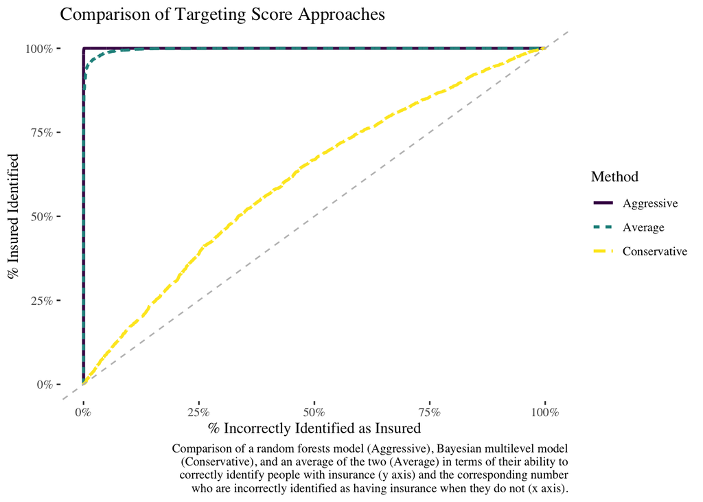

This is good news in that the model performs well on what we could call the “training” data, i.e., the data that TMH provided for Texas. However, we might want to be concerned because no model is perfect and the performance is almost suspiciously high. A model is a simplified representation of what people do, and in the real world we can never predict with complete certainty how many will or will not purchase insurance. For these reasons, I added a third targeting score, which is the average of the aggressive and conservative approaches. This line, which is included as a green dotted line in the plot above, has slightly less performance than the aggressive approach but still performs remarkably well.

The plot below shows the targeting score predictions for the three modeling approaches for each resident in the Houston data:

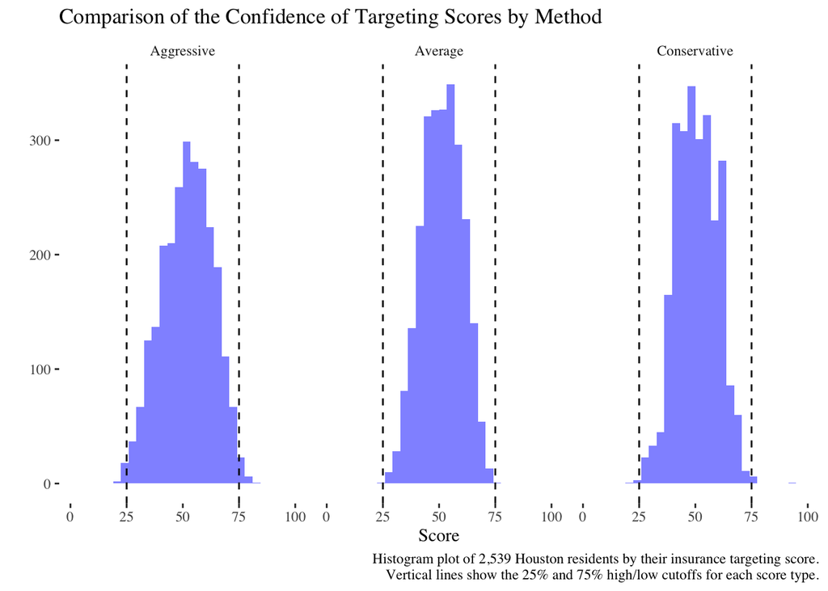

The plot above shows that for each method, the most common targeting score is 50%, or about a coin flip in terms of whether the person would or would not purchase insurance given the chance to do so. The vertical lines show the score cutoffs at 25% and 75%, indicating the number of people who the models are able to differentiate as being very likely or very unlikely to purchase insurance. On the whole, these plots reveal that the targeting scores for the Houston residents are relatively imprecise even though the models, especially the aggressive approach, are quite accurate on the training data.

The reason that the models are not as confident on the Houston data is because the people in Houston do not generally belong to categories (demographics and personal beliefs) that contain a lot of information about whether they might purchase insurance. As a result, for this particular set of people, we can only classify relatively few as being very likely or unlikely to purchase insurance, though as I show below, that does not mean our ad targeting scores aren’t useful for optimizing ad spend.

The finished targeting scores are included as a CSV file with ranks for the aggressive, average and conservative scores in addition to raw values. The CSV is sorted by the aggressive score with the highest-scoring individuals at the top of the file.

## Using the Targeting Score

It is very important to emphasize to the client that employing the targeting score will improve their ability to use ad spending effectively, but at the same time it is not a perfect method. Some people that our targeting score identifies as being very likely to purchase insurance may not in fact do so; others whom we identify as being relatively unlikely to purchase may still do so. For these reasons, to employ the scores effectively requires knowing the client’s particular budget and other constraints. Specifically, we would want to know:

1. What is the client’s total ad budget for this market?
2. How much priority is the client putting on revenue growth vs. profitability?
3. What is the client’s risk tolerance?

To illustrate these issues, suppose that the client has an ad budget of $10,000. We assume that they would need to spend $100 to inform a Houston resident of one of their insurance plans. We’ll that on each plan TMH receives a net revenue of $150 after costs. Without targeting information, their best option could randomly select 1,000 of the 2,539 in the Houston data to spend $100 and receive an ad. We can compare this type of uninformed targeting to a situation in which we instead use our ad targeting criteria to target the ads at the 1,000 most likely to purchase insurance. If we assume that our aggressive model’s predictions are as accurate as they appear, we can repeat a simulation of ad targeting 100 times to see how much profit over ad spend TMH might receive relative to purely random ad targeting:

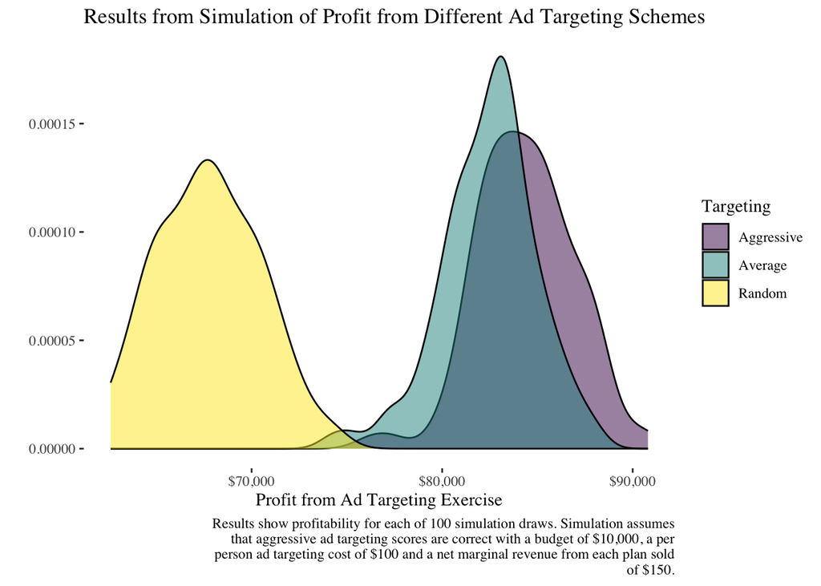

As the plot shows, given the fixed budget of $10,000 for ad spend and a product marginal revenue of $150, there is a substantial increase in profit from using the targeting scores. The aggressive scores perform better than the average scores, but the difference is relatively marginal. Whether or not the client wants to use aggressive scores may depend on their own risk profile and their corporate strategy vis-a-vis growth.

To emphasize how these scores work in terms of company context, the plot below repeats the simulation exercise but instead lowers the total budget to $5,000, the per-person advertising cost to $150 and raises the product net marginal revenue to $350:

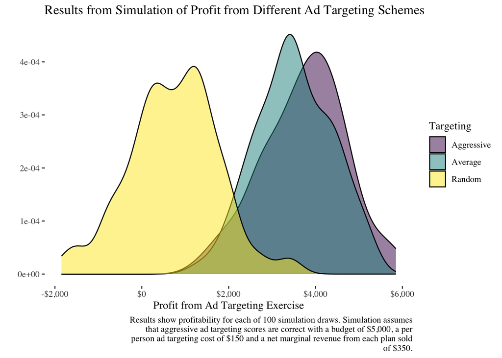

We can see that with a lower advertising budget there is still substantial reason to believe that the targeting scores will improve profitability by as much as $4,000 over random targeting. However, there is more uncertainty and essentially less utility to using the scores with a smaller budget.

To summarize, the scores are certaintly better than targeting without information, but the exact impact on the bottom line depends on the cost of the product, the cost of advertising and the amount of resources that the client is willing to devote to the advertising effort. Designing simulations like those above based on actual client financials could help in designing an optimal ad targeting budget given the expected performance of the targeting scores.

## Footnotes

[^1]: I should note that legal should look into the potential risks of working with a monopolist that has to be in violation of anti-trust regulations.